# BUAN 5510 - Capstone Project - EDA

Keith Castelino and Sourabh Gupta

December 03, 2019

# 1 Prepare your environment

Following needs to be done in order to prepare your environment:

- Clean environment of all variables, functions and packages
- Load packages required for analysis (only those that are required)
- Set colour preferences for graphs
- Load custom functions

Read in the raw data, as is required.

```r
#loading data
#
# xlsx files -- Data for SU Part 1 - Filed Cases and Hearings
D11_filed_cases <- read_excel("../Data/Data for SU Part 1 - Filed Cases and Hearings.xlsx", sheet = "FiledCases SU") %>% clean_names()
D12_case_event <- read_excel("../Data/Data for SU Part 1 - Filed Cases and Hearings.xlsx", sheet = "CaseEvents SU") %>% clean_names()
# D13_case_event_key <- read_excel("../Data/Data for SU Part 1 - Filed Cases and Hearings.xlsx", sheet = "CaseEvent Key") %>% clean_names()
D14_case_type <- read_excel("../Data/Data for SU Part 1 - Filed Cases and Hearings.xlsx", sheet = "CaseType Key") %>% clean_names()
#
# xlsx files -- Data for SU Part 2
D21_charge <- read_excel("../Data/Data for SU Part 2.xlsx", sheet = "SU Charges") %>% clean_names()
D22_charge_def <- read_excel("../Data/Data for SU Part 2.xlsx", sheet = "Charge Definitions") %>% clean_names()
D23_dispo_key <- read_excel("../Data/Data for SU Part 2.xlsx", sheet = "Disposition Key") %>% clean_names()
# D24_crime_hist <- read_excel("../Data/Data for SU Part 2.xlsx", sheet = "SU CrimHist") %>% clean_names()
#
# xlsx files -- Data for SU Part 3 - custody history
D31_custody_hist <- read_excel("../Data/Data for SU Part 3 - custody history.xlsx", sheet = "CustodyHistory SU") %>% clean_names()

# treated events_with_missing_status
events_with_missing_def_status <- read.csv("../calculated_data/events_with_missing_def_status.csv", header = TRUE)
#

#----------------------  Received new Data for D24 and D13  -----------------#
D13_case_event_key <- read_excel("../Data/Data for SU Part 4 - cleaned criminal history and updated hearing key.xlsx", sheet = "CaseEvent Key") %>% clean_names()
D24_crime_hist <- read_excel("../Data/Data for SU Part 4 - cleaned criminal history and updated hearing key.xlsx", sheet = "SU CrimHist") %>% clean_names()
```

# 2 Cleaning the Data

To ensure that data is fit for analysis, we need to do the following:

- Data structure: Ensure that the columns within each table are defined correctly
  - Confirm the data type is per expectation, and matches with definition in data dictionary
- Derived variables: Define new columns based on data provided that are important factors for analysis

Summary for each of the datasets are below:

## 2.1 D11_filed_cases

```r
D11_filed_cases <- D11_filed_cases %>%
  mutate(
    dob_anon = ymd(dob_anon),
    event_enter_date = mdy(event_enter_date),
    age = interval(dob_anon, event_enter_date) %/% years(1),
    age_group = cut(
      age, breaks = c(0, 18, 30, 40, 50, 60, 80),
      labels = c("LE_18", "20-30", "30-40", "40-50", "50-60", "GE_60"),
      order = TRUE
    ),
    venue = fct_collapse(venue, Other = c("DCS", "DCW", "JUV"))
  ) %>%
  mutate_at(c("gender", "venue", "case_types"), factor) %>%
  select(-c(dob_anon, referral_date, event_code, police_agency, anon_le_number))

replace_na(list(gender = "Unknown"))
```

```
## $gender
## [1] "Unknown"
```

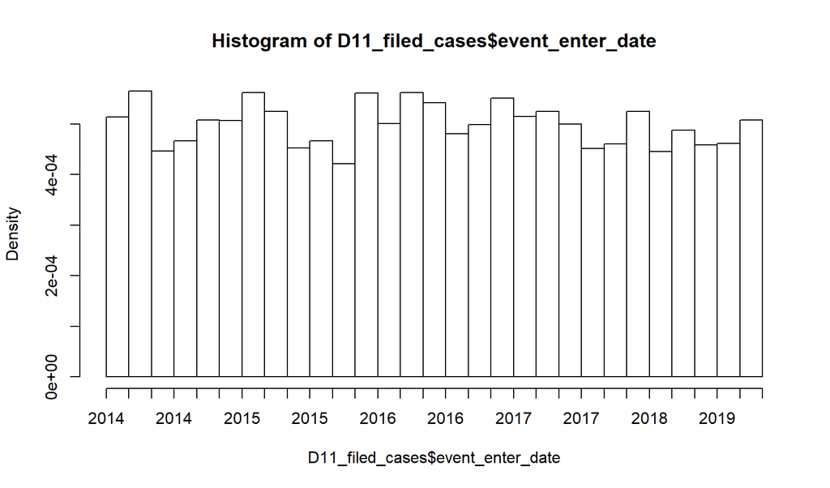

```r
# write.csv(D11_filed_cases, '../calculated_data/D11_filed_cases.csv')  # for Basic Stat : PowerBI Visuals, Snapshot included below

hist(D11_filed_cases$event_enter_date, breaks = seq(min(D11_filed_cases$event_enter_date), max(D11_filed_cases$event_enter_date), length.out = 30))
```

```r
summary(D11_filed_cases)
```

```
##  file_number         defendant_id         gender
##  Length:34237       Min.   :    171   Female : 5220
##  Class :character   1st Qu.: 416269   Male   :28977
##  Mode  :character   Median : 519296   Unknown:    3
##                     Mean   : 689763   NA's   :   37
##                     3rd Qu.:1049234
##                     Max.   :1204864
##
##                                         case_types    event_enter_date
##  VUCSA                                       : 3602   Min.   :2014-01-02
##  Domestic violence                           : 2424   1st Qu.:2015-05-07
##  Domestic violence, Intimate Partner Violence: 2180   Median :2016-09-19
##  Car Theft Initiative                        : 1590   Mean   :2016-09-20
##  eDiscovery                                  : 1447   3rd Qu.:2018-01-23
##  (Other)                                     :14963   Max.   :2019-06-28
##  NA's                                        : 8031
##    venue            age         age_group
##  Other:   21   Min.   : 14.00   LE_18:  938
##  KNT  :15137   1st Qu.: 25.00   20-30:14948
##  SEA  :19079   Median : 32.00   30-40: 9751
##                Mean   : 33.82   40-50: 5252
##                3rd Qu.: 41.00   50-60: 2645
##                Max.   :118.00   GE_60:  680
##                                 NA's :   23
```

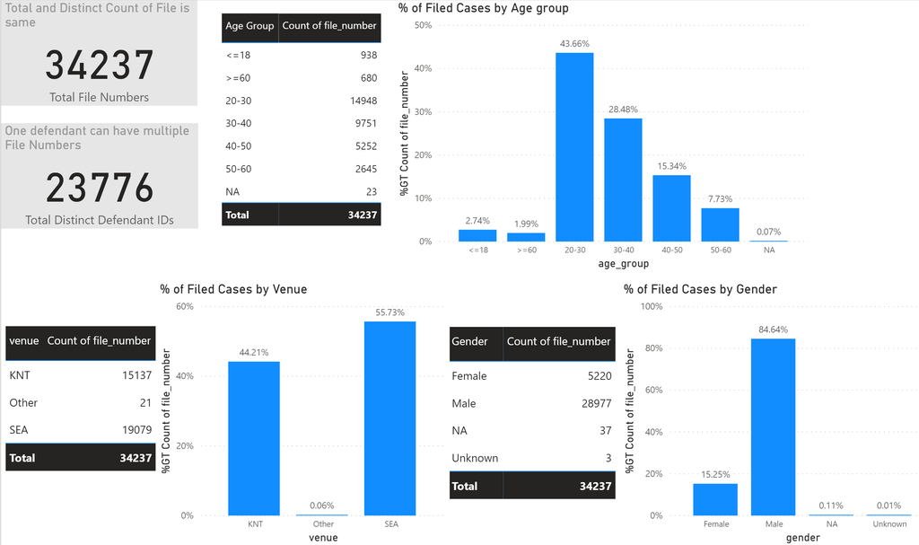

D11

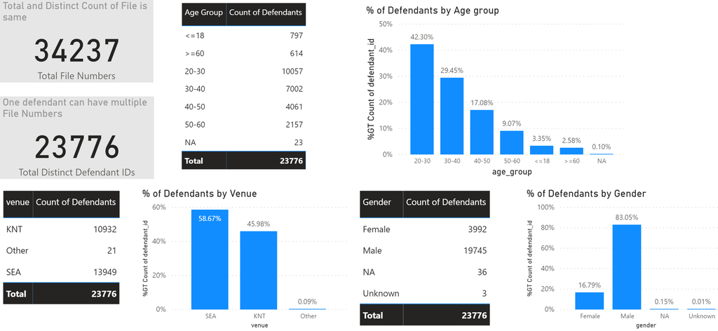

Missing Values: + We have `37 + 3 = 40` records where Gender is either missing or unknown + Case type has `8031` records with missing data + We don’t have age or age group for 23 filed cases + Max age is 118, this is odd

## 2.2 D12_case_event

- One record = one event within a case
  - There is no **level** to this data
- Event Docket Date: indicates the date of a future hearing
- Event Code: indicates if the defendant failed to appear
  - missing values may include some `DEFFTA`
  - need to crosscheck with `Custody History SU` to fill up missing values in `Defendant Event Status`
- We do not require these columns -> `Case Types`, `Venue`

```r
# event enter date is required to check when DFA happend
D12_case_event <- D12_case_event %>%
  mutate(event_docket_date = ymd(event_docket_date)) %>%
  mutate_at(c("defendant_event_status", "event_code"), factor) %>%
  select(-c(case_types, venue))

summary(D12_case_event)
```

```
##  file_number         defendant_id       event_code
##  Length:632464      Min.   :    171   HRCS   :191702
##  Class :character   1st Qu.: 412645   HRARRSC: 44690
##  Mode  :character   Median : 514471   CSHNOWV: 43686
##                     Mean   : 675062   LECSREC: 34552
##                     3rd Qu.:1042544   HRDR1  : 34435
##                     Max.   :1204864   HROMCON: 34092
##                                       (Other):249307
##  event_enter_date              event_docket_date    defendant_event_status
##  Min.   :2014-01-01 00:00:00   Min.   :2001-02-19   EHD :  1109
##  1st Qu.:2015-10-12 00:00:00   1st Qu.:2015-11-06   IN  :218552
##  Median :2017-03-02 00:00:00   Median :2017-03-30   OUT :155439
##  Mean   :2017-01-25 12:05:38   Mean   :2017-02-21   WER :  2172
##  3rd Qu.:2018-05-17 00:00:00   3rd Qu.:2018-06-16   NA's:255192
##  Max.   :2019-09-01 00:00:00   Max.   :2020-05-12
##                                NA's   :140515
```

```r
# write.csv(D12_case_event, '../calculated_data/D12_case_event.csv')
```

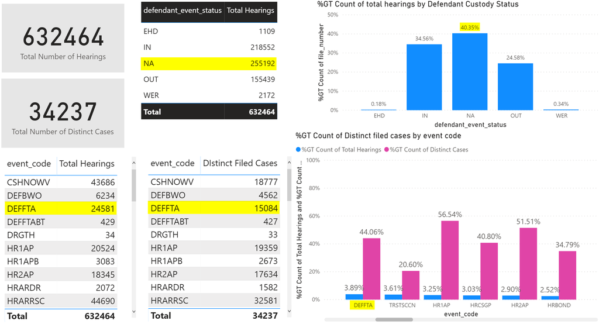

D12

Missing Values: + We have `140515` records where event docket date is missing + We have `255192` records where Defendant event status is missing

## 2.3 D13_case_event_key

- Case stages need to be classified in 4 ways:
  - Arraignment
  - Pre Case Setting
  - Case Setting
  - Post Case Setting
- We know what the following codes mean:
  - HRARRSC: Arraignment
  - HRCSGP, HRCSNWK, HRCSNWS, HRCSWK, HRCSWS: Case setting
- Pre Case Setting: Any event that is after the last arraignment date
- Post Case Setting: Any event that is after the first case setting date

```r
### ----------  Now we have case_stage from DAVID, No mutation required now  ---------- ###
### ----------  Commentiing the code  ------------------------------------------------- ###

# D13_case_event_key <- D13_case_event_key %>%
#   # mutate_at(c("hearing_code"), factor) %>%
#   mutate(
#     case_setting_stage = fct_collapse(
#       hearing_code,
#       arraignment = c("HRARRSC"),                                                      #--- (+) SG
#       case_setting = c("HRCS", "HRCSGP", "HRCSNWK", "HRCSNWS", "HRCSWK", "HRCSWS"),
#       # before = c(
#       #   "CSHNOWV", "DEFBWO", "DRGTH", "HR1AP", "HR1APB",
#       #   "HR2AP", "HRBOND", "HRCOMP", "HRCOMPAR",
#       #   "HRCOMPBS", "HRCOMPCS", "HRCOMPKA", "HRCOMPKC",
#       #   "HRCOMPKT", "HRCOMPTR", "HRCPLSNT", "HRCRMO"
#       # ),
#       # after = c(
#       #   "HRCTCOMP", "HROM", "HROMCON", "HRPLEA", "HRPT", "HRSNTSC", "HRSTATCF",
#       #   "LECSREC", "MOCCAP", "TRSTSC", "TRSTSCCN", "WARARRDC", "WARARRSC"
#       # ),
#       drug_court = c("HRARDR", "HRBWSC", "HRDR1", "HRDR2", "HRDRC")                    #--- (+) SG: others -> drug_court
#     ))
#   # ) %>%
#   # replace_with_na(list(case_setting_stage = c("DEFFTA", "DEFFTABT")))
```

## 2.4 D14_case_type

This dataset does not map to anything, so we will ignore it.

## 2.5 D21_charge

- Offense end date treated the same as start date if not missing
- Additional columns:
  - we have defined if charges are enhanced -> new calculated column `charge_enhanced` as Yes / No
- We do not require these columns -> `Referral Date`, `Referral Charge(s)`, `Original Charge(s)`, `Warning`, `Description`

```r
# D21_charge <- read_excel("../Data/Data for SU Part 2.xlsx", sheet = "SU Charges") %>% clean_names()

D21_charge <- D21_charge %>%
  mutate_at(c("offense_start_date", "offense_end_date", "filing_date", "disposition_date"), mdy) %>%
  # mutate_at(c("disposition_code"), factor) %>%
  mutate(
    offense_end_date = if_else(is.na(offense_end_date), offense_start_date, offense_end_date),
    charge_enhanced = if_else(is.na(enhancements), "No", "Yes"),
    charge_code = str_to_upper(str_trim(
      str_split(string = current_charge_s, pattern = '-', n = 2, simplify = TRUE)[,1]
    ))
  ) %>%
  select(-c(referral_date, referral_charge_s, original_charge_s, warning, current_charge_s, description, enhancements))

# write.csv(D21_charge, '../calculated_data/D21_charge.csv')
summary(D21_charge)
```

```
##  file_number        offense_start_date   offense_end_date
##  Length:72030       Min.   :1980-04-08   Min.   :1980-04-08
##  Class :character   1st Qu.:2014-12-24   1st Qu.:2015-01-10
##  Mode  :character   Median :2016-05-20   Median :2016-06-02
##                     Mean   :2016-04-11   Mean   :2016-05-07
##                     3rd Qu.:2017-09-27   3rd Qu.:2017-10-07
##                     Max.   :2019-08-25   Max.   :2019-09-05
##                     NA's   :4            NA's   :3
##   filing_date         disposition_date     disposition_code
##  Min.   :2014-01-02   Min.   :2001-02-17   Length:72030
##  1st Qu.:2015-05-06   1st Qu.:2015-10-09   Class :character
##  Median :2016-09-12   Median :2017-01-31   Mode  :character
##  Mean   :2016-09-18   Mean   :2017-01-22
##  3rd Qu.:2018-01-22   3rd Qu.:2018-04-30
##  Max.   :2019-06-28   Max.   :2019-09-17
##                       NA's   :8665
##  charge_enhanced    charge_code
##  Length:72030       Length:72030
##  Class :character   Class :character
##  Mode  :character   Mode  :character
##
##
##
##
```

- There are 8665 records where `disposition date` is empty
- There are records where `filing date` is after the `disposition date`, need to confirm with David
- Data Quality Issues
- D21_charge:
  - There are 36 records where the filing date is earlier than the earliest offense start date
  - There are 1731 records where the filing date is earlier than the offense start date

```r
# D21_charge %>%
#   group_by(file_number) %>%
#   mutate(min_offense_start = min(offense_start_date)) %>%
#   filter(filing_date < min_offense_start)
#
# D21_charge %>%
#   filter(filing_date < offense_start_date)
```

## 2.6 D22_charge_def

- Charges classed as:
  - felony v/s misdemeanour
  - violent v/s non-violent

```r
D22_charge_def <- D22_charge_def %>%
  mutate(
    code = if_else(str_detect(code, "[A-Z]"), code, str_pad(code, 5, "left", "0")),
    # charge_class = case_when(
    #   class %in% c('A', 'B', 'C') ~ 2,                            # "Felony",
    #   class %in% c('U', 'GM') ~ 1,                                # "Misdemeanour",
    #   TRUE ~ 0                                                    # "Other"
    # ),
    is_violent = if_else(violent == 1, 1, 0)                      # "Yes", "No/Maybe"
  ) %>%
  # mutate_at(c("charge_class", "is_violent"), factor) %>%
  mutate(
    # charge_class = factor(
    #   charge_class, levels = c(0, 1, 2), ordered = TRUE                      # c("Other", "Misdemeanour", "Felony")
    # ),
    is_violent = factor(is_violent, levels = c(0, 1), ordered = TRUE),        # c("No/Maybe", "Yes")
    class = factor(class, levels = c('U', 'I', 'M', 'GM', 'C', 'B', 'A'), ordered = TRUE),
  ) %>%
  select(-c(violent))
```

## 2.7 D23_dispo_key

- Description used to identify the verdict (this is an approximation)
- Disposition type is recategorized

```r
D23_dispo_key <- D23_dispo_key %>%
  # mutate_at(c("type"), factor) %>%
  mutate(
    type = fct_collapse(type, Other = c("Dismissed", "Decline or Other/Error")),
    verdict = case_when(
      str_detect(tolower(description), "guilty") ~ "guilty",
      str_detect(tolower(description), "acquit") ~ "acquitted",
      TRUE ~ "other"
    ),
    dispo_type = case_when(
      str_detect(tolower(type), "trial")     ~ "trial",
      str_detect(tolower(type), "plea")      ~ "plea",
      str_detect(tolower(type), "dismissal") ~ "dismissal",
      TRUE ~ "dismissal"
    )
  ) %>%
  mutate_at(c("verdict", "dispo_type"), factor)

# delete records where ranking is 5
D23_dispo_key <- D23_dispo_key %>%
   filter(ranking != 5)
```

## 2.8 D24_crime_hist

- Confirmed that “Display Sequence” is based on the order of offenses
- Historical records classified based on age group and charge class
- In-state v/s Out-of-state history identified
- Three new columns are introduced -> `history_in_state`, `last_crime_period`, `total_crimes`

```r
D24_crime_hist <- D24_crime_hist %>%
  mutate(
    jurisdiction_state = str_extract(jursidiction, "\\b[A-Z]{2}"),
    age_group = if_else(startsWith(conviction_level, 'J'), "juvenile", "adult"),
    charge_class = if_else(endsWith(conviction_level, 'M'), "misdemeanour", "felony"),
    history_in_state = jurisdiction_state == 'WA',
    last_crime = as.numeric((Sys.Date() - as.Date(offense_date)) / 365),
    last_crime_period = cut(
      last_crime, breaks = c(0, 3, 10, 110),
      labels = c("<=3", "3-10", ">10")
    )
  ) %>%
  group_by(defendant_id) %>%
  mutate(total_crimes = length(defendant_id)) %>%
  select(-c(jurisdiction_state, conviction_level, last_crime)) %>%
  ungroup()

# criminal history sort by recent crime per defendant id
crime_hist_by_def <- D24_crime_hist %>%
                        group_by(defendant_id) %>%
                        arrange(last_crime_period) %>%
                        slice(1) %>%
                        ungroup()

summary(D24_crime_hist)
```

```
##   defendant_id     display_sequence charge_description
##  Min.   :    171   Min.   :  1.00   Length:276588
##  1st Qu.: 273115   1st Qu.:  3.00   Class :character
##  Median : 423252   Median :  9.00   Mode  :character
##  Mean   : 497376   Mean   : 12.57
##  3rd Qu.: 523318   3rd Qu.: 18.00
##  Max.   :1204667   Max.   :123.00
##
##   offense_date                 conviction_date
##  Min.   :1900-12-21 00:00:00   Min.   :1929-11-10 00:00:00
##  1st Qu.:1999-09-16 00:00:00   1st Qu.:2001-05-16 00:00:00
##  Median :2008-03-01 00:00:00   Median :2009-08-17 00:00:00
##  Mean   :2006-05-25 21:01:48   Mean   :2007-11-20 20:12:10
##  3rd Qu.:2014-01-30 00:00:00   3rd Qu.:2015-10-16 00:00:00
##  Max.   :9116-10-03 00:00:00   Max.   :6200-01-21 00:00:00
##  NA's   :483                   NA's   :150338
##  jursidiction           link            age_group
##  Length:276588      Length:276588      Length:276588
##  Class :character   Class :character   Class :character
##  Mode  :character   Mode  :character   Mode  :character
##
##
##
##
##  charge_class       history_in_state last_crime_period  total_crimes
##  Length:276588      Mode :logical    <=3 : 22433       Min.   :  1.00
##  Class :character   FALSE:30652      3-10: 97320       1st Qu.: 13.00
##  Mode  :character   TRUE :212103     >10 :156330       Median : 22.00
##                     NA's :33833      NA's:   505       Mean   : 25.85
##                                                        3rd Qu.: 35.00
##                                                        Max.   :123.00
##
```

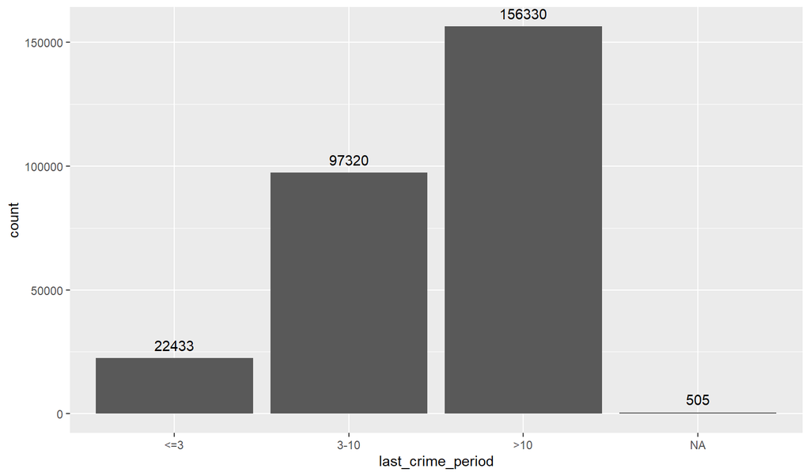

```r
ggplot(D24_crime_hist, aes(x = last_crime_period)) +
  geom_bar() +
geom_text(stat='count', aes(label=..count..), vjust=-0.7)
```

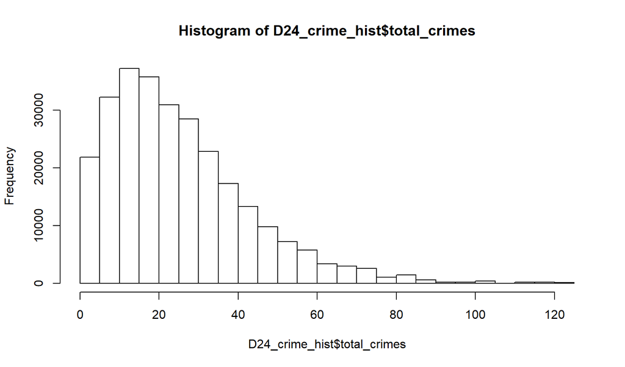

```r
hist(D24_crime_hist$total_crimes)
```

## 2.9 D31_custody_hist

```r
D31_custody_hist <- D31_custody_hist %>%
  mutate_at(c("current_status", "custody_status_history", "status_update_user"), factor) %>%
  mutate(
    status_update_user = fct_lump(status_update_user, other_level = "OTHER"),
    status_history_date = excel_numeric_to_date(as.numeric(status_history_date), "modern"),
    current_status_date = as.Date(current_status_date)
  )
```

## 2.10 Further data cleaning

The data is further trimmed based on the following:

```r
# classifying case types that occur less than 1% as "Other"
# missing case types classified as "Unknown"

# D11_filed_cases %>%
#   diagnose_category(top = 25, add_character = TRUE) %>%
#   filter(variables == "case_types") %>%
#   arrange(desc(freq))

D11_filed_cases <- D11_filed_cases %>%
  mutate(
    # case_types = fct_lump(case_types, prop = 0.01),
    case_types = fct_explicit_na(case_types, na_level = "Unknown"),
    age_group = fct_explicit_na(age_group, na_level = "Unknown")
  ) %>%
  replace_na(list(gender = "Unknown"))

# D12_case_event <- D12_case_event %>%
#   filter(!(is.na(event_docket_date) & event_code != "DEFFTA"))

# D21_charge <- D21_charge %>%
#   filter(!(is.na(disposition_date) | is.na(disposition_code)))
```

### 2.10.1 Missing values for defendant event status

Highlight all lines and hit Ctrl+C to uncomment

Need to read in the CSV file to work with it for further EDA

```r
# remove all the duplicates
events_with_missing_def_status <- events_with_missing_def_status[!duplicated(events_with_missing_def_status), ]

# keep only records where there is DEFFTA, and first event_enter_date of each file_number
events_with_missing_def_status <- events_with_missing_def_status[events_with_missing_def_status$event_code == 'DEFFTA', ] %>%
                        group_by(file_number) %>%
                        arrange(file_number, event_enter_date) %>%
                        slice(1) %>%
                        ungroup() %>%
                        select(-c(event_code, event_enter_date, event_docket_corrected))
```

## 2.11 Data Cleaning has been completed, now the analysis

## 2.12 Capstone Meeting Updates - 10/22/2019

1. Representative charge for each File Number as one File Number may have multiple charges. -> `D11_cases_rep_charge`
2. Critical stage of a case is case setting (Arraignment, case setting, before case setting, after case setting) -> `case_stage_by_file`
3. Last Arraignment Date -> `last_arr_date_by_file`
4. Filling missing Defendant_Event_Status field in CaseEvents table -> `events_with_missing_status`

## 2.13 Representative Charges

- representative charge for each File Number as one File Number may have multiple charges.
- Datasets required –> D21, D22
- Order of precedence -> Charge Class, Seriousness, violent

```r
# join D21_charge and D22_charge_def to get charge class, seriousness and violent information for each file number
represent_charge_by_file <- left_join(D21_charge, D22_charge_def, by = c("charge_code" = "code"))

# Drug cases definition 1
drug_case_desc <- represent_charge_by_file
drug_case_desc$drug_case <- ifelse(grepl("Violation of the Uniform Controlled Substances Act", represent_charge_by_file$description), "yes", "no")
# filter records where drug_case is 'yes'
drug_case_desc <- drug_case_desc[drug_case_desc$drug_case == 'yes', ] %>%
                    select(c(file_number))

# join 'represent_charge_by_file' and 'D23_dispo_key' to get type of disposition (Trail, Plea, Dismissal)
represent_charge_by_file <- left_join(represent_charge_by_file, D23_dispo_key, by = c("disposition_code"))

# arrange/sort records as File_number-ASC, Class-DESC, Seriousness-DESC, Violent-DESC
represent_charge_by_file <- represent_charge_by_file %>%
                              group_by(file_number) %>%
                              arrange(file_number, desc(class),
                                    desc(seriousness), desc(is_violent)) %>%
                              slice(1) %>%
                              ungroup()  %>%
                              select(-c(offense_start_date, offense_end_date, filing_date, disposition_date, disposition_code,
                                        charge_enhanced, description.x, description.y, ranking, type, verdict))
```

## 2.14 Critical stage of a case is case setting (Arraignment, case setting, before case setting, after case setting)

```r
# D12_case_events and D13_case_event_key to map the hearing codes to get 3 things, arraignment, case_setting, drug_court
cs_1 <- left_join(D12_case_event, D13_case_event_key, by = c("event_code" = "hearing_code")) %>%
          select(-c(description))

# filter records where case is drug_Case
drug_court <- cs_1[cs_1$hearing_event_classification == 'Drug Court', ] %>%
                select(c(file_number))

# filter records where case has competency hearing
compt_cases <- cs_1[cs_1$hearing_event_classification == 'Competency', ]

# last arraignment date for each file number
last_arr_date_by_file <- cs_1[cs_1$hearing_event_classification == 'Arraignment', ] %>%
                        select(-c(defendant_id, event_code, event_enter_date, defendant_event_status)) %>%
                        group_by(file_number) %>%
                        arrange(file_number, desc(event_docket_date)) %>%
                        slice(1) %>%
                        ungroup()

colnames(last_arr_date_by_file)[colnames(last_arr_date_by_file) == 'event_docket_date'] <- 'last_arr_date'
colnames(last_arr_date_by_file)[colnames(last_arr_date_by_file) == 'hearing_event_classification'] <- 'arraignment'

# first case setting date for each file number
first_cs_date_by_file <- cs_1[cs_1$hearing_event_classification == 'Case Setting', ] %>%
                        select(-c(defendant_id, event_code, event_enter_date, defendant_event_status)) %>%
                        group_by(file_number) %>%
                        arrange(file_number, event_docket_date) %>%
                        slice(1) %>%
                        ungroup()

colnames(first_cs_date_by_file)[colnames(first_cs_date_by_file) == 'event_docket_date'] <- 'first_cs_date'
colnames(first_cs_date_by_file)[colnames(first_cs_date_by_file) == 'hearing_event_classification'] <- 'case_setting'

# join 3 dataframes (cs_1, last_arr_date_by_file, first_cs_date_by_file) to get last_arraignment_date and first_case_setting_date for each file number
cs_2 <- left_join(cs_1, last_arr_date_by_file, by = c("file_number")) %>%
                                select(-c(arraignment))
cs_2 <- left_join(cs_2, first_cs_date_by_file, by = c("file_number")) %>%
                                select(-c(case_setting))

###### # new column with 4 categories: A(Arraignment), B(Before Case Setting), C(Case Setting), D(After Case Setting)
###### case_stage_by_file <- cs_2 %>%
######       mutate(case_stage = ifelse(case_setting_stage == 'drug_court', 'E(Drug court)',
######                             ifelse(event_docket_date <= last_arr_date , 'A(Arraignment)',
######                               ifelse(event_docket_date > last_arr_date & event_docket_date < first_cs_date, 'B(Before Case Setting)',
######                                 ifelse(event_docket_date == first_cs_date, 'C(Case Setting)',
######                                   ifelse(event_docket_date > first_cs_date, 'D(After Case Setting)', event_code)))))) %>%
######   select(-c(case_setting_stage))

# filter only records where event_code is DEFFTA
dfa_file_cases <- cs_1[cs_1$event_code == 'DEFFTA', ]

###### # new column with 5 categories: A(Arraignment), B(Before Case Setting), C(Case Setting), D(After Case Setting), E(Drug court)
###### case_stage_by_file <- case_stage_by_file %>%
######       mutate(case_stage_dfa =ifelse(is.na(case_stage), (ifelse((!is.na(last_arr_date) | (!is.na(last_arr_date) & is.na(first_cs_date))) & event_enter_date <= last_arr_date , 'A(Arraignment)',
######                                 ifelse((!is.na(first_cs_date) & !is.na(last_arr_date)) & (event_enter_date < first_cs_date & event_enter_date > last_arr_date), 'B(Before Case Setting)',
######                                   ifelse(!is.na(first_cs_date) & event_enter_date == first_cs_date, 'C(Case Setting)',
######                                     ifelse(!is.na(first_cs_date) & event_enter_date > first_cs_date, 'D(After Case Setting)',
######                                       ifelse(is.na(first_cs_date) & is.na(last_arr_date), 'E(Drug court)',
######                                         ifelse((((is.na(last_arr_date) & !is.na(first_cs_date)) & event_enter_date < first_cs_date) | ((!is.na(last_arr_date) & is.na(first_cs_date)) & event_enter_date > last_arr_date)), 'B(Before Case Setting)', case_stage))))))), case_stage))

###### # keeping only records which have these 5 values as above
###### case_stage_by_file = filter(case_stage_by_file, (case_stage_dfa %in% c("A(Arraignment)", "B(Before Case Setting)", "C(Case Setting)", "D(After Case Setting)", "E(Drug court)")))

# # total DFA by file
# dfa_file_cases <- dfa_file_cases %>%
#                     group_by(file_number) %>%
#                     summarise(total_dfa = sum(event_code == "DEFFTA"))

# Earliest DEFFTA  at which stage for each file number
dfa_file_cases <- dfa_file_cases %>%
                    group_by(file_number) %>%
                    mutate(total_dfa = length(which(event_code == "DEFFTA"))) %>%
                    arrange(file_number, event_enter_date) %>%
                    slice(1) %>%
                    select(c(file_number, hearing_event_classification, total_dfa)) %>%
                    ungroup()

# # new column in "case_stage_by_file" matching with "dfa_file_cases" to check if filed case has DEFFTA
# case_stage_by_file$dfa <- ifelse(is.na(match(case_stage_by_file$file_number, dfa_file_cases$file_number)),"No", "Yes")

# Remove un-necessary datasets
rm(cs_1, cs_2, case_stage_by_file)
```

## 2.15 preparing dataset for DFA rate EDA in powerBI

```r
# We need DFA rates of per file_number by
# Age, Age-group, Gender, Venue      -- in D11_filed_cases dataset
# charge class, seriousness, violent -- in represent_charge_by_file
# Criminal History                   -- in D24_crime_hist / crime_hist_by_file
# Critical stage of case, total dfa  -- in dfa_file_cases
# Custody Status                     -- events_with_missing_value
# Drug case(Yes/No)                  -- in drug_cases
# Competency Case(Yes/No)            -- in compt_cases

rm(dfa_by_category, dfa_for_model)

### Age-group, Gender, Venue, charge class, seriousness, violent per file number
dfa_by_category <- merge(x = D11_filed_cases, y = represent_charge_by_file, by = "file_number", all.x=TRUE) %>%
                      select(-c(event_enter_date))

### new column in "dfa_by_category" matching with "D24_crime_hist" to get criminal history status in Yes or No
dfa_by_category$crime_hist <- ifelse(is.na(match(dfa_by_category$defendant_id, D24_crime_hist$defendant_id)),"No", "Yes")

### now for the files which have DFA atleast once with stage of the case -- case_stage_by_file
dfa_by_category <- merge(x = dfa_by_category, y = dfa_file_cases, by = "file_number", all.x=TRUE)
  # fill total_dfa value nas with 0
dfa_by_category$total_dfa[is.na(dfa_by_category$total_dfa)] <- 0
  # new column in "dfa_by_category" matching with "dfa_file_cases" to check if filed case has DFA - yes/no
dfa_by_category$dfa <- ifelse(is.na(match(dfa_by_category$file_number, dfa_file_cases$file_number)),"No", "Yes")

### adding custody status of the defendant as well
dfa_by_category <- merge(x = dfa_by_category, y = events_with_missing_def_status, by = c("file_number", "defendant_id"), all.x=TRUE)

### Case charge is drug charge - Yes/No
dfa_by_category$drug_charge <- ifelse(is.na(match(dfa_by_category$file_number, drug_case_desc$file_number)),"No", "Yes")

### Case went into drug court - Yes/No
dfa_by_category$drug_court <- ifelse(is.na(match(dfa_by_category$file_number, drug_court$file_number)),"No", "Yes")

### Case has atleast one competency hearing - Yes/No
dfa_by_category$compt_case <- ifelse(is.na(match(dfa_by_category$file_number, compt_cases$file_number)),"No", "Yes")

### Club GM, M, I, U as one class - GM
dfa_by_category <- dfa_by_category %>%
                    mutate(class= recode(class, "c('GM', 'M', 'U', 'I')='GM'"))

### new dummy variable for age <=18
dfa_by_category$le_18 <- ifelse(dfa_by_category$age <= 18, "Yes", "No")

### new dummy variable for age >=60
dfa_by_category$ge_60 <- ifelse(dfa_by_category$age >= 60, "Yes", "No")

# export dfa_by_category to csv for powerbi
write.csv(dfa_by_category, '../calculated_data/dfa_by_category_eda.csv')

summary(dfa_by_category)
```

```
##  file_number         defendant_id         gender
##  Length:34237       Min.   :    171   Female : 5220
##  Class :character   1st Qu.: 416269   Male   :28977
##  Mode  :character   Median : 519296   Unknown:   40
##                     Mean   : 689763
##                     3rd Qu.:1049234
##                     Max.   :1204864
##
##                                         case_types      venue
##  Unknown                                     : 8031   Other:   21
##  VUCSA                                       : 3602   KNT  :15137
##  Domestic violence                           : 2424   SEA  :19079
##  Domestic violence, Intimate Partner Violence: 2180
##  Car Theft Initiative                        : 1590
##  eDiscovery                                  : 1447
##  (Other)                                     :14963
##       age           age_group     charge_code         class
##  Min.   : 14.00   LE_18  :  938   Length:34237       A   : 1945
##  1st Qu.: 25.00   20-30  :14948   Class :character   B   :12475
##  Median : 32.00   30-40  : 9751   Mode  :character   C   :14150
##  Mean   : 33.82   40-50  : 5252                      GM  : 5642
##  3rd Qu.: 41.00   50-60  : 2645                      NA's:   25
##  Max.   :118.00   GE_60  :  680
##                   Unknown:   23
##   seriousness   is_violent       dispo_type     crime_hist
##  Min.   : 0.0   0   :27898   dismissal: 6435   Length:34237
##  1st Qu.: 0.1   1   : 4458   plea     :21945   Class :character
##  Median : 2.0   NA's: 1881   trial    : 1039   Mode  :character
##  Mean   : 2.6                NA's     : 4818
##  3rd Qu.: 4.0
##  Max.   :16.0
##  NA's   :1881
##  hearing_event_classification   total_dfa          dfa
##  Length:34237                 Min.   : 0.000   Length:34237
##  Class :character             1st Qu.: 0.000   Class :character
##  Mode  :character             Median : 0.000   Mode  :character
##                               Mean   : 0.718
##                               3rd Qu.: 1.000
##                               Max.   :10.000
##
##  defendant_status drug_charge         drug_court         compt_case
##  EHD :   11       Length:34237       Length:34237       Length:34237
##  IN  :  366       Class :character   Class :character   Class :character
##  OUT :14079       Mode  :character   Mode  :character   Mode  :character
##  WER :    8
##  NA's:19773
##
##
##     le_18              ge_60
##  Length:34237       Length:34237
##  Class :character   Class :character
##  Mode  :character   Mode  :character
##
##
##
##
```

```r
# summary(D11_filed_cases)
```

```r
# dfa_for_model <- dfa_by_category %>%
#                       select(-c(case_types, charge_code, file_number, defendant_id))
#
# # 1. delete records where gender is "Unknown"
# dfa_for_model <- dfa_for_model[!(dfa_for_model$gender=="Unknown"),]
# # 2. FIll nas in age with mean of the column
# # dfa_for_model <- dfa_for_model[, age := na.aggregate(age)]
#
# # fill missing of seriousness
# class_serious <- D22_charge_def %>%
#                   group_by(class) %>%
#                   dplyr::summarize(Mean = mean(seriousness, na.rm=TRUE))
#
# class_serious <- class_serious[!is.na(class_serious$class),]
#
# dfa_for_model$seriousness[is.na(dfa_for_model$seriousness)] <- class_serious$Mean[match(dfa_for_model$class, class_serious$class)][which(is.na(dfa_for_model$seriousness))]
#
# rm(class_serious)
#
#
# # mean(my.xldataset$mcs1, na.rm=TRUE)
#
# dfa_for_model$class <- ifelse(is.na(dfa_for_model$class), 'Other', dfa_for_model$class)
# dfa_for_model$class <- as.factor(dfa_for_model$class)
#
# dfa_for_model$seriousness <- ifelse(is.na(dfa_for_model$seriousness), 99, dfa_for_model$seriousness)
# dfa_for_model$seriousness <- as.factor(dfa_for_model$seriousness)
#
# dfa_for_model$is_violent <- ifelse(is.na(dfa_for_model$is_violent), 0, dfa_for_model$is_violent)
#
# dfa_for_model$defendant_status <- ifelse(is.na(dfa_for_model$defendant_status), 'Other', dfa_for_model$defendant_status)
# dfa_for_model$defendant_status <- as.numeric(as.factor(dfa_for_model$defendant_status))
#
# dfa_for_model$gender      <- as.numeric(dfa_for_model$gender)
# dfa_for_model$venue       <- as.numeric(dfa_for_model$venue)
# # dfa_for_model$age_group   <- as.numeric(dfa_for_model$age_group)
# dfa_for_model$class       <- as.numeric(dfa_for_model$class)
# dfa_for_model$is_violent  <- as.numeric(dfa_for_model$is_violent)
# dfa_for_model$case_stage_dfa   <- as.numeric(as.factor(dfa_for_model$case_stage_dfa))
#
# # dfa_for_model$dfa <- ifelse(dfa_for_model$dfa == 'Yes', 1, 0)
# dfa_for_model$crime_hist <- ifelse(dfa_for_model$crime_hist == 'Yes', 1, 0)
#
#
# str(dfa_for_model)
# summary(dfa_for_model)
#
# # export dfa_by_category to csv for powerbi
# write.csv(dfa_for_model, '../calculated_data/dfa_for_model.csv')
```

# 3 DFA Rate by Category

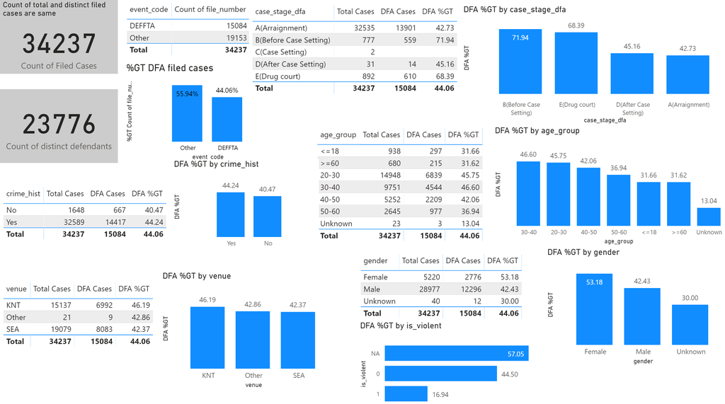

DFA_1

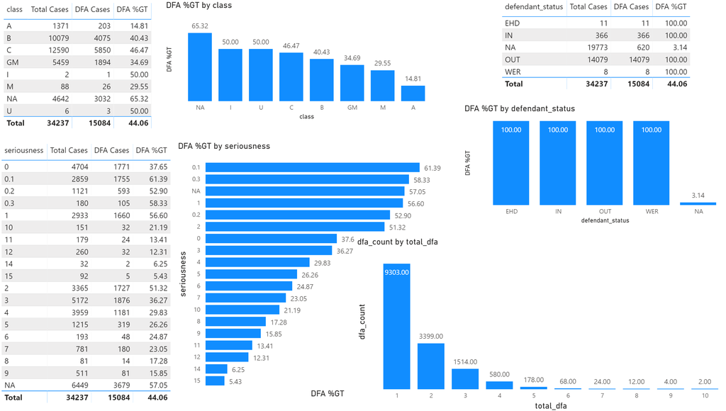

DFA_2

# 4 Disposition time

## 4.1 Data Preparation

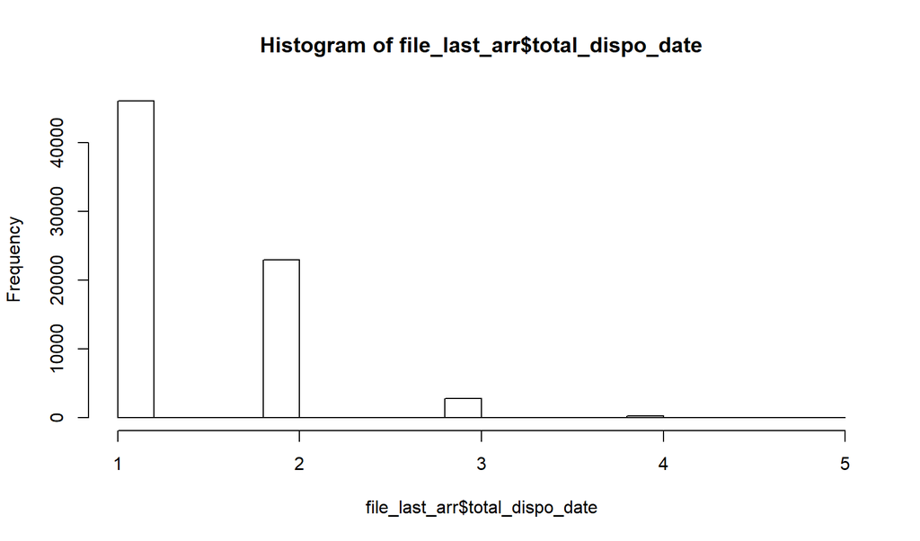

```r
# megre D21_charges table with last_arr_date_by_file to get last arraignement date for each file number
# new columns : (i)   total_dispo_date   -> how many disposition date one file number has
#               (ii)  dispo_time_filing  -> time to disposition comparing filing date
#               (iii) dispo_time_arraign -> time to disposition comparing last arraignement date of file
file_last_arr <- merge(x = D21_charge, y = last_arr_date_by_file, by = "file_number", all.x=TRUE) %>%
                        group_by(file_number) %>%
                          mutate(total_dispo_date = length(unique(disposition_date))) %>%
                        ungroup() %>%
                          mutate(dispo_time_filing  = as.Date(disposition_date) - as.Date(filing_date)) %>%
                          mutate(dispo_time_arraign = as.Date(disposition_date) - as.Date(last_arr_date)) %>%
                            select(-c(arraignment, offense_start_date, offense_end_date))

# convert new column in to numeric datatype
file_last_arr$dispo_time_filing  <- as.numeric(as.character(file_last_arr$dispo_time_filing))
file_last_arr$dispo_time_arraign <- as.numeric(as.character(file_last_arr$dispo_time_arraign))

# histogram for count of disposition date
hist(file_last_arr$total_dispo_date)
```

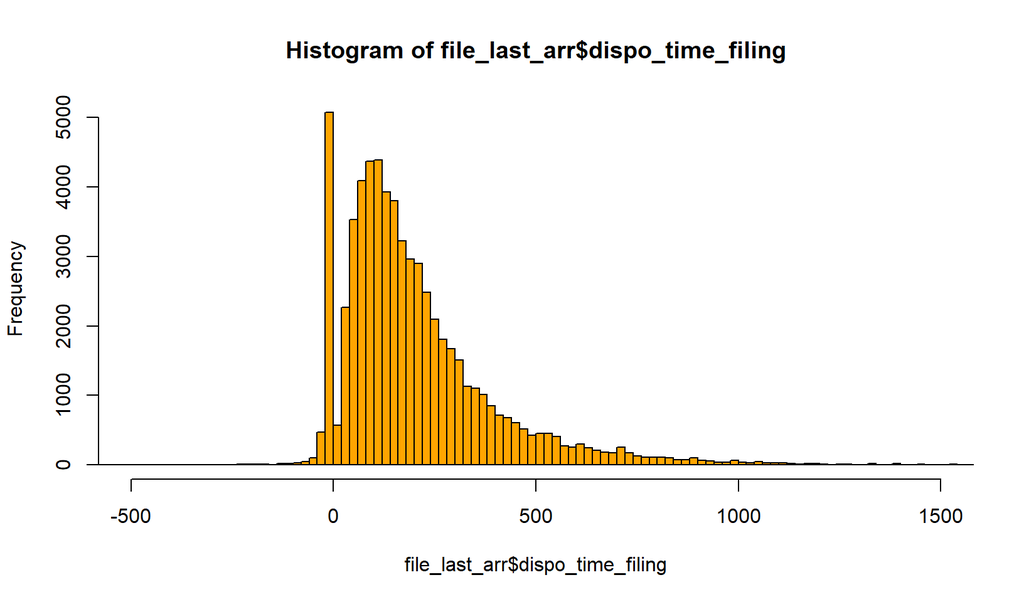

```r
# histogram for time to disposition comparing filing date
hist(file_last_arr$dispo_time_filing, col="orange",
     xlim=c(-500,1500), breaks=280)
```

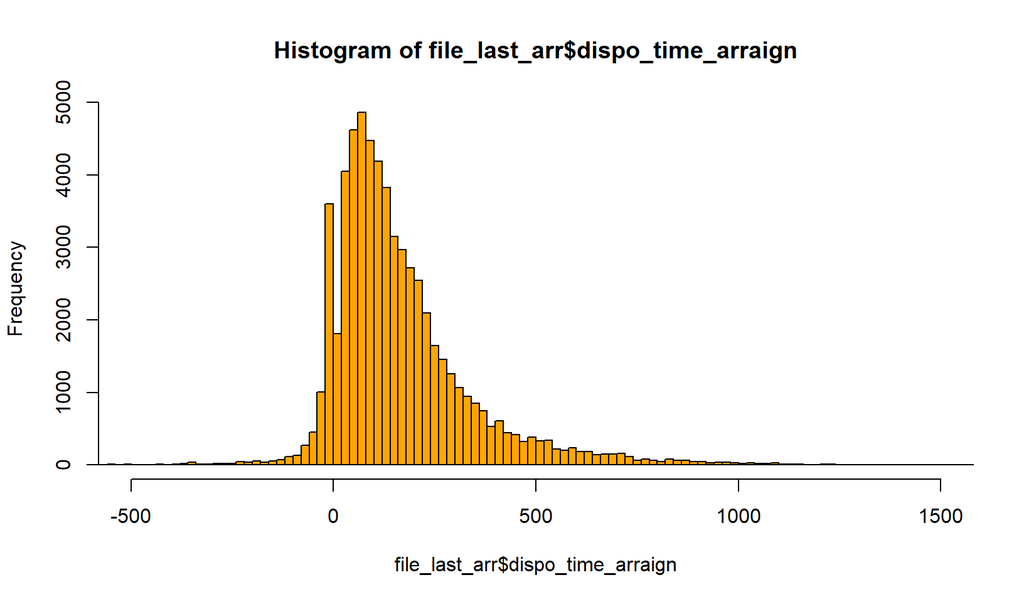

```r
# histogram for time to disposition comparing last arraignement date of file
hist(file_last_arr$dispo_time_arraign, col="orange",
     xlim=c(-500,1500), breaks=280)
```

```r
# rm(file_last_arr)
```

```r
# merge file_last_arr with D23_dispo_key to get disposition ranking
dispo_time_dispo_rank <- merge(x = file_last_arr, y = D23_dispo_key, by = "disposition_code", all.x=TRUE) %>%
                            group_by(file_number) %>%
                            arrange(file_number, desc(ranking)) %>%
                            slice(1) %>%
                            ungroup() %>%
                          select(c(file_number, filing_date, disposition_date, charge_enhanced, charge_code, last_arr_date,
                                   total_dispo_date, dispo_time_filing, dispo_time_arraign, disposition_code, ranking))

rm(file_last_arr)

# for each file number in dispo_time_dispo_rank dataframe, get from dfa_by_category df
# Age, Age-group, Gender, Venue
# charge class, seriousness, violent
# hearing_event_stage
# Criminal History
# Custody Status
# drug case (Yes/No), Competency case (Yes/No)
# total dfa by file
dispo_by_category <- merge(x = dispo_time_dispo_rank, y = dfa_by_category, by = "file_number", all.x=TRUE) %>%
      mutate(serious_cat = ifelse(seriousness <= 5, '<=5',
                            ifelse(seriousness > 5 & seriousness <= 10, '5-10',
                              ifelse(seriousness > 5, '>10', seriousness))))  %>%
                         select(-c(filing_date, last_arr_date, case_types, charge_code.y,
                                   seriousness))

# # export dfa_by_category to csv
write.csv(dispo_by_category, '../calculated_data/dispo_by_category.csv')
```

## 4.2 Filing date - Histogram and Basic stats

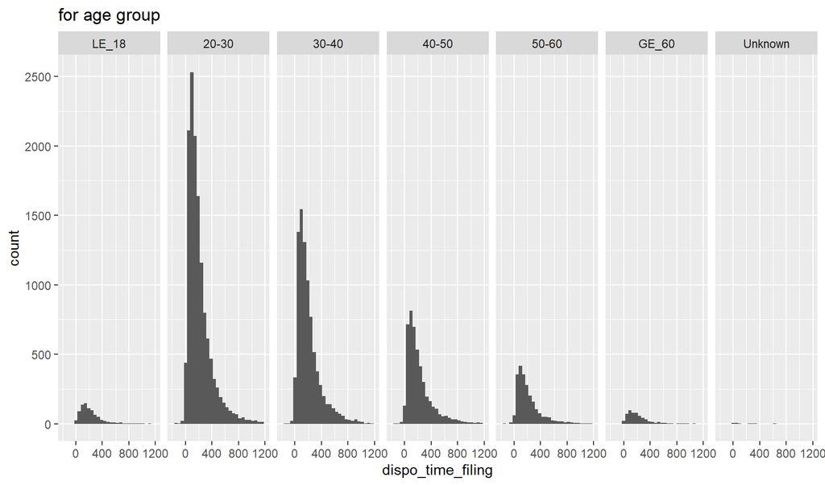

```r
# disposition time comparing filing date for age group
ggplot(dispo_by_category,aes(x=dispo_time_filing)) +
  geom_histogram()  +
    xlim(c(-200,1200)) + facet_grid(~age_group) + ggtitle("for age group")
```

```r
# age group
summaryBy(dispo_time_filing ~ age_group, data = dispo_by_category,
          FUN = list(mean, max, min, median), na.rm=TRUE)
```

```
##   age_group dispo_time_filing.mean dispo_time_filing.max
## 1     LE_18               217.7488                  1134
## 2     20-30               209.2656                  1967
## 3     30-40               207.2992                  1768
## 4     40-50               221.5632                  1848
## 5     50-60               218.7236                  1568
## 6     GE_60               220.0407                  1681
## 7   Unknown               134.6111                   621
##   dispo_time_filing.min dispo_time_filing.median
## 1                  -271                    176.0
## 2                 -2711                    155.0
## 3                 -5687                    156.0
## 4                  -620                    161.5
## 5                  -149                    161.0
## 6                   -18                    180.0
## 7                     6                     63.0
```

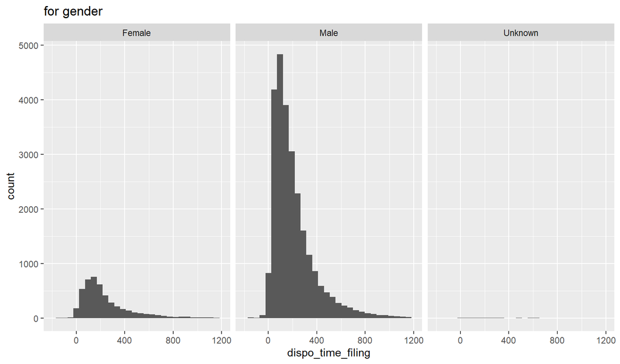

```r
#-----------------------------------------------------

# disposition time comparing filing date for gender
ggplot(dispo_by_category,aes(x=dispo_time_filing)) +
  geom_histogram()  +
    xlim(c(-200,1200)) + facet_grid(~gender) + ggtitle("for gender")
```

```r
# gender
summaryBy(dispo_time_filing ~ gender, data = dispo_by_category,
          FUN = list(mean, max, min, median), na.rm=TRUE)
```

```
##    gender dispo_time_filing.mean dispo_time_filing.max
## 1  Female               237.2832                  1848
## 2    Male               207.1571                  1967
## 3 Unknown               161.1724                   621
##   dispo_time_filing.min dispo_time_filing.median
## 1                 -2711                      176
## 2                 -5687                      155
## 3                     6                       85
```

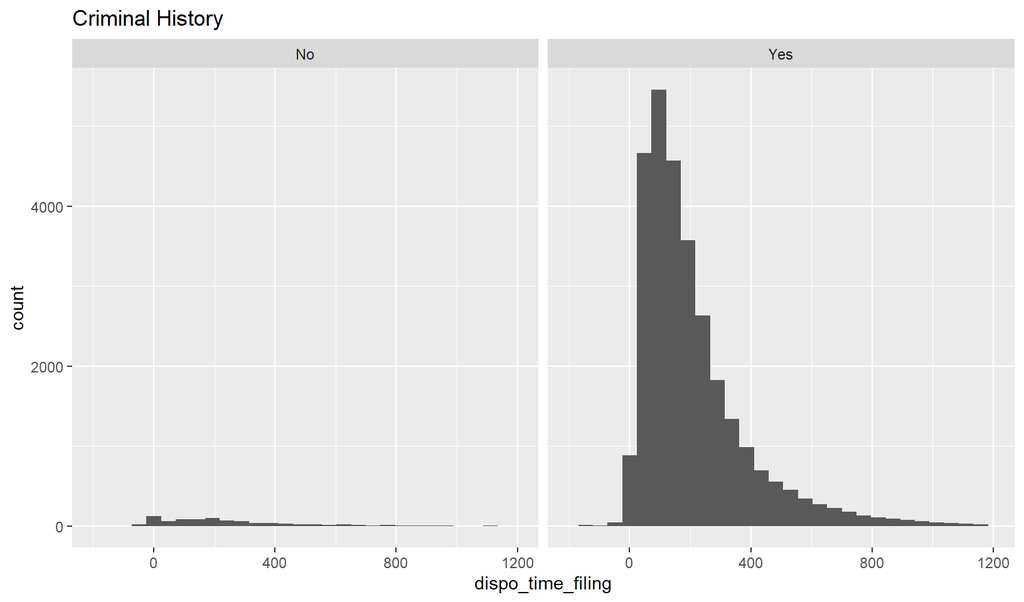

```r
#-----------------------------------------------------

# disposition time comparing filing date for Criminal History
ggplot(dispo_by_category,aes(x=dispo_time_filing)) +
  geom_histogram()  +
    xlim(c(-200,1200)) + facet_grid(~crime_hist) + ggtitle("Criminal History")
```

```r
# crime_hist
summaryBy(dispo_time_filing ~ crime_hist, data = dispo_by_category,
          FUN = list(mean, max, min, median), na.rm=TRUE)
```

```
##   crime_hist dispo_time_filing.mean dispo_time_filing.max
## 1         No               245.3350                  1709
## 2        Yes               210.7536                  1967
##   dispo_time_filing.min dispo_time_filing.median
## 1                   -65                      189
## 2                 -5687                      157
```

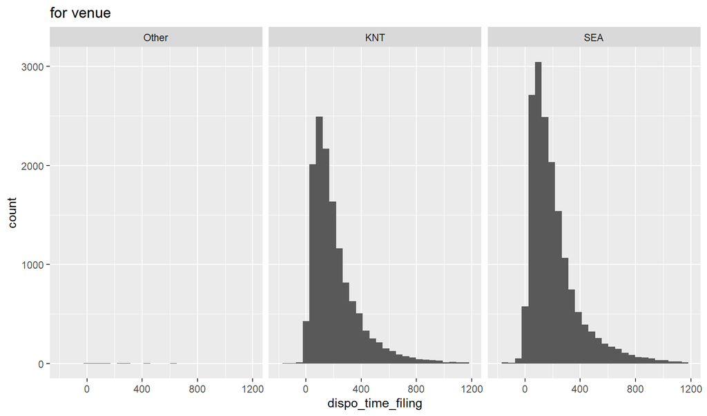

```r
#-----------------------------------------------------

# disposition time comparing filing date for venue
ggplot(dispo_by_category,aes(x=dispo_time_filing)) +
  geom_histogram()  +
    xlim(c(-200,1200)) + facet_grid(~venue) + ggtitle("for venue")
```

```r
# venue
summaryBy(dispo_time_filing ~ venue, data = dispo_by_category,
          FUN = list(mean, max, min, median), na.rm=TRUE)
```

```
##   venue dispo_time_filing.mean dispo_time_filing.max dispo_time_filing.min
## 1 Other               151.0000                   630                    12
## 2   KNT               210.1851                  1967                 -2711
## 3   SEA               212.9490                  1848                 -5687
##   dispo_time_filing.median
## 1                      104
## 2                      159
## 3                      158
```

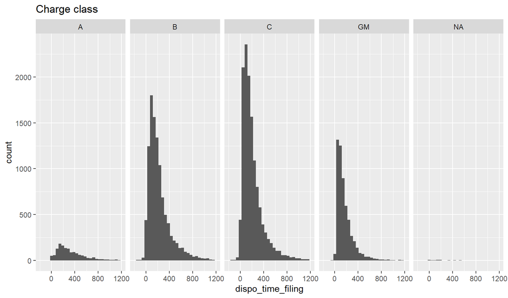

```r
#-----------------------------------------------------

# disposition time comparing filing date for Charge class
ggplot(dispo_by_category,aes(x=dispo_time_filing)) +
  geom_histogram()  +
    xlim(c(-200,1200)) + facet_grid(~class) + ggtitle("Charge class")
```

```r
# class
summaryBy(dispo_time_filing ~ class, data = dispo_by_category,
          FUN = list(mean, max, min, median), na.rm=TRUE)
```

```
##   class dispo_time_filing.mean dispo_time_filing.max dispo_time_filing.min
## 1     A               325.5667                  1883                  -218
## 2     B               225.5528                  1659                 -1708
## 3     C               206.3949                  1967                 -5687
## 4    GM               168.6456                  1397                 -2473
## 5  <NA>               164.7391                   537                     0
##   dispo_time_filing.median
## 1                      262
## 2                      173
## 3                      154
## 4                      126
## 5                      162
```

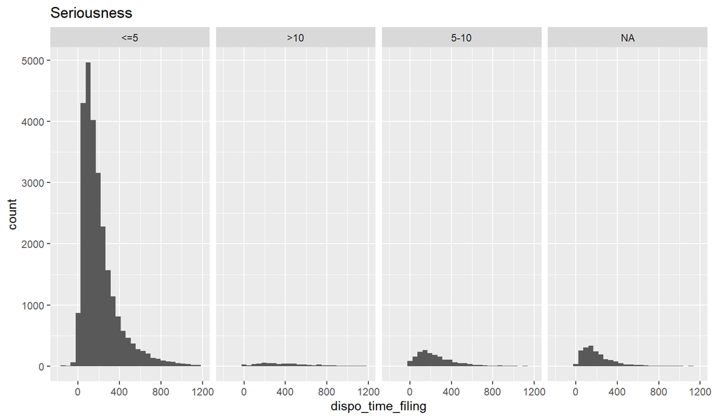

```r
#-----------------------------------------------------

# disposition time comparing filing date for Seriousness
ggplot(dispo_by_category,aes(x=dispo_time_filing)) +
  geom_histogram()  +
    xlim(c(-200,1200)) + facet_grid(~serious_cat) + ggtitle("Seriousness")
```

```r
# serious_cat
summaryBy(dispo_time_filing ~ serious_cat, data = dispo_by_category,
          FUN = list(mean, max, min, median), na.rm=TRUE)
```

```
##   serious_cat dispo_time_filing.mean dispo_time_filing.max
## 1         <=5               204.6973                  1967
## 2         >10               403.4071                  1732
## 3        5-10               249.3502                  1883
## 4        <NA>               212.7719                  1749
##   dispo_time_filing.min dispo_time_filing.median
## 1                 -5687                    153.0
## 2                    -2                    354.5
## 3                  -413                    202.0
## 4                  -223                    167.0
```

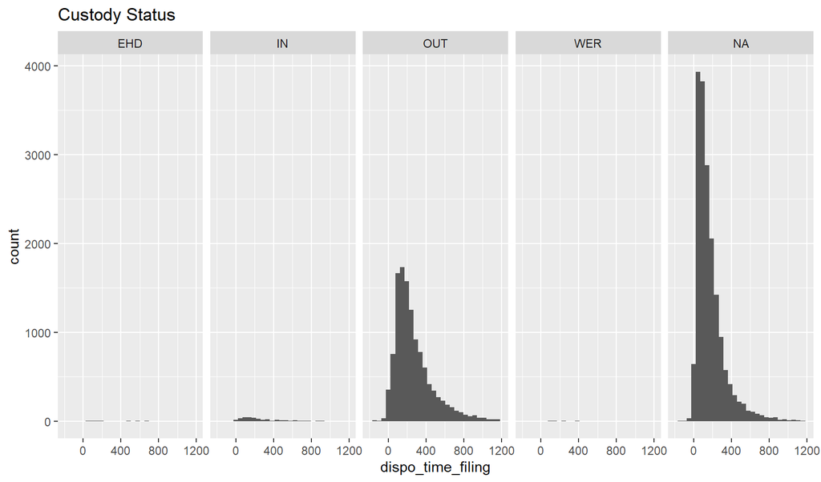

```r
#-----------------------------------------------------

# disposition time comparing filing date for Custody Status
ggplot(dispo_by_category,aes(x=dispo_time_filing)) +
  geom_histogram()  +
    xlim(c(-200,1200)) + facet_grid(~defendant_status) + ggtitle("Custody Status")
```

```r
# defendant_status
summaryBy(dispo_time_filing ~ defendant_status, data = dispo_by_category,
          FUN = list(mean, max, min, median), na.rm=TRUE)
```

```
##   defendant_status dispo_time_filing.mean dispo_time_filing.max
## 1              EHD               306.0000                   657
## 2               IN               253.7119                  1523
## 3              OUT               270.0381                  1967
## 4              WER               217.7143                   386
## 5             <NA>               172.3628                  1883
##   dispo_time_filing.min dispo_time_filing.median
## 1                    54                    181.5
## 2                   -20                    184.0
## 3                 -2825                    211.0
## 4                   118                    234.0
## 5                 -5687                    129.0
```

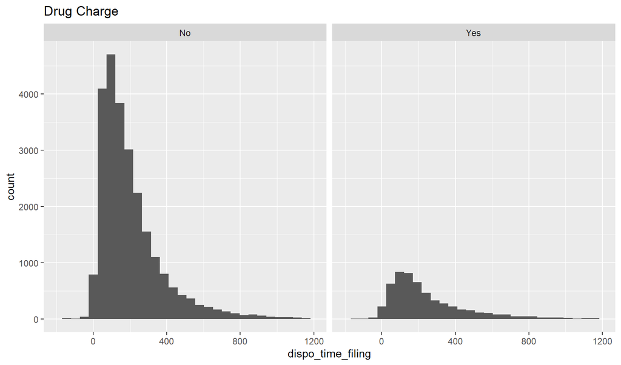

```r
#-----------------------------------------------------

# disposition time comparing filing date for Drug Cases
ggplot(dispo_by_category,aes(x=dispo_time_filing)) +
  geom_histogram()  +
    xlim(c(-200,1200)) + facet_grid(~drug_charge) + ggtitle("Drug Charge")
```

```r
# drug_court
summaryBy(dispo_time_filing ~ drug_charge, data = dispo_by_category,
          FUN = list(mean, max, min, median), na.rm=TRUE)
```

```
##   drug_charge dispo_time_filing.mean dispo_time_filing.max
## 1          No               203.6237                  1967
## 2         Yes               248.4099                  1848
##   dispo_time_filing.min dispo_time_filing.median
## 1                 -2825                      154
## 2                 -5687                      182
```

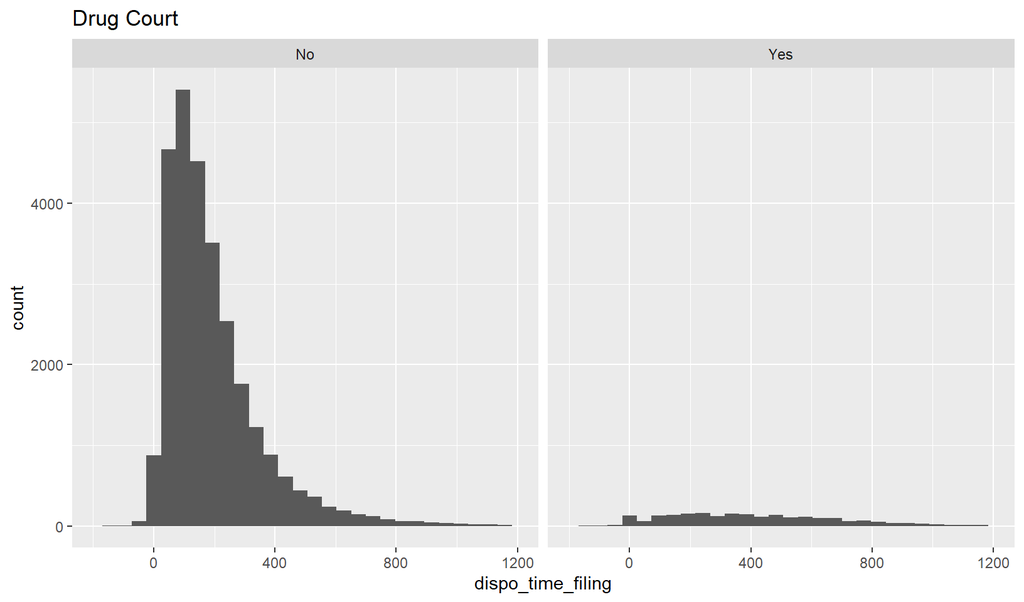

```r
#-----------------------------------------------------

# disposition time comparing filing date for Drug Cases
ggplot(dispo_by_category,aes(x=dispo_time_filing)) +
  geom_histogram()  +
    xlim(c(-200,1200)) + facet_grid(~drug_court) + ggtitle("Drug Court")
```

```r
# drug_court
summaryBy(dispo_time_filing ~ drug_court, data = dispo_by_category,
          FUN = list(mean, max, min, median), na.rm=TRUE)
```

```
##   drug_court dispo_time_filing.mean dispo_time_filing.max
## 1         No               194.8613                  1967
## 2        Yes               420.5999                  1848
##   dispo_time_filing.min dispo_time_filing.median
## 1                 -5687                      151
## 2                  -287                      381
```

```r
#-----------------------------------------------------
```

## 4.3 last Arraignment date - Histogram and Basic stats

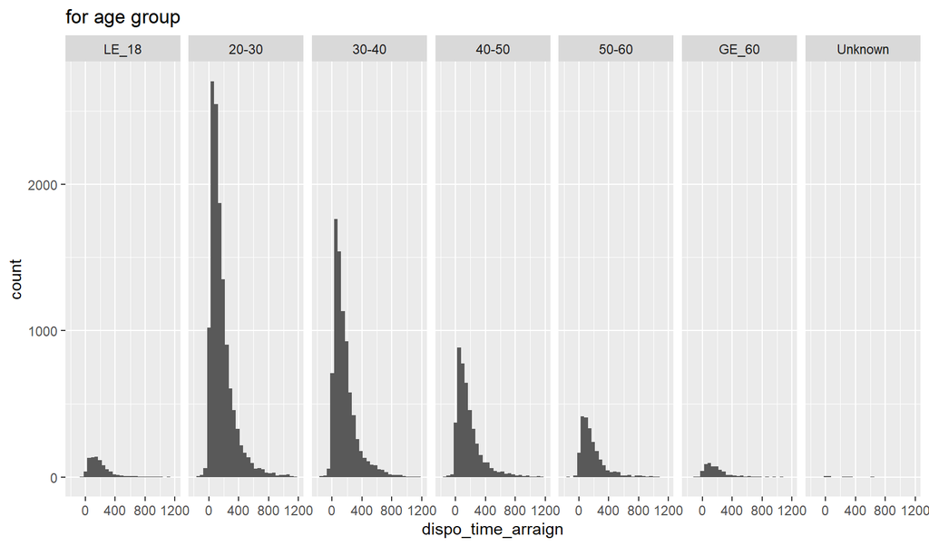

```r
# disposition time comparing last arraignment date for age group
ggplot(dispo_by_category,aes(x=dispo_time_arraign)) +
  geom_histogram()  +
    xlim(c(-200,1200)) + facet_grid(~age_group) + ggtitle("for age group")
```

```r
# age group
summaryBy(dispo_time_arraign ~ age_group, data = dispo_by_category,
          FUN = list(mean, max, min, median), na.rm=TRUE)
```

```
##   age_group dispo_time_arraign.mean dispo_time_arraign.max
## 1     LE_18                188.5771                   1120
## 2     20-30                166.5519                   1871
## 3     30-40                163.0088                   1754
## 4     40-50                176.8363                   1719
## 5     50-60                179.5941                   1546
## 6     GE_60                188.9113                   1666
## 7   Unknown                120.3889                    608
##   dispo_time_arraign.min dispo_time_arraign.median
## 1                   -317                     153.0
## 2                  -2723                     121.0
## 3                  -5700                     121.0
## 4                   -735                     129.0
## 5                   -188                     133.0
## 6                    -80                     146.0
## 7                     -7                      51.5
```

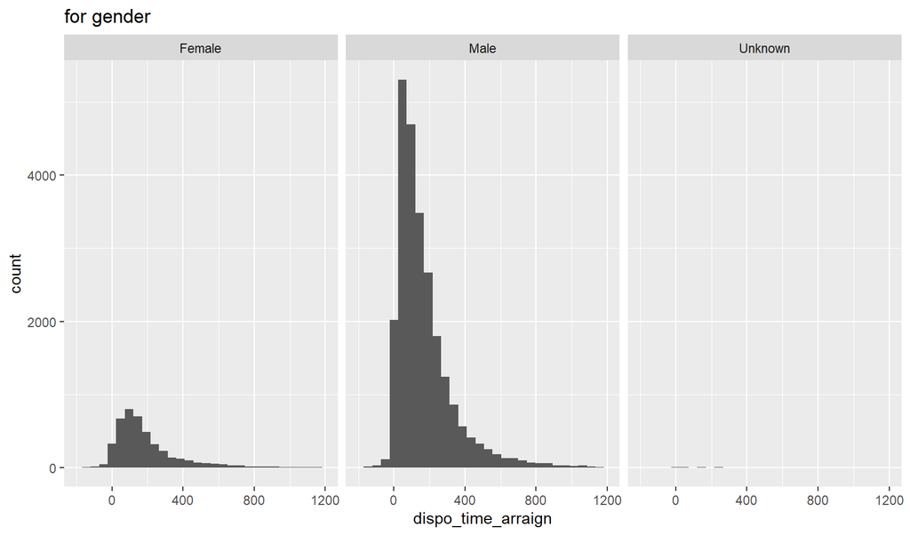

```r
#-----------------------------------------------------

# disposition time comparing last arraignment date for gender
ggplot(dispo_by_category,aes(x=dispo_time_arraign)) +
  geom_histogram()  +
    xlim(c(-200,1200)) + facet_grid(~gender) + ggtitle("for gender")
```

```r
# gender
summaryBy(dispo_time_arraign ~ gender, data = dispo_by_category,
          FUN = list(mean, max, min, median), na.rm=TRUE)
```

```
##    gender dispo_time_arraign.mean dispo_time_arraign.max
## 1  Female                185.4277                   1696
## 2    Male                166.3089                   1871
## 3 Unknown                110.5000                    608
##   dispo_time_arraign.min dispo_time_arraign.median
## 1                  -2723                       140
## 2                  -5700                       122
## 3                     -7                        51
```

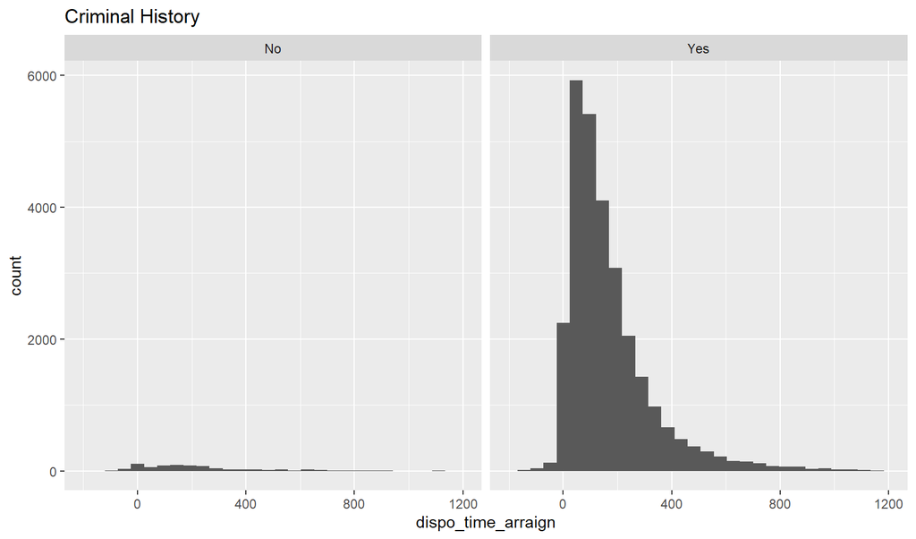

```r
#-----------------------------------------------------

# disposition time comparing last arraignment date for Criminal History
ggplot(dispo_by_category,aes(x=dispo_time_arraign)) +
  geom_histogram()  +
    xlim(c(-200,1200)) + facet_grid(~crime_hist) + ggtitle("Criminal History")
```

```r
# crime_hist
summaryBy(dispo_time_arraign ~ crime_hist, data = dispo_by_category,
          FUN = list(mean, max, min, median), na.rm=TRUE)
```

```
##   crime_hist dispo_time_arraign.mean dispo_time_arraign.max
## 1         No                209.9602                   1696
## 2        Yes                167.9965                   1871
##   dispo_time_arraign.min dispo_time_arraign.median
## 1                  -1477                       166
## 2                  -5700                       125
```

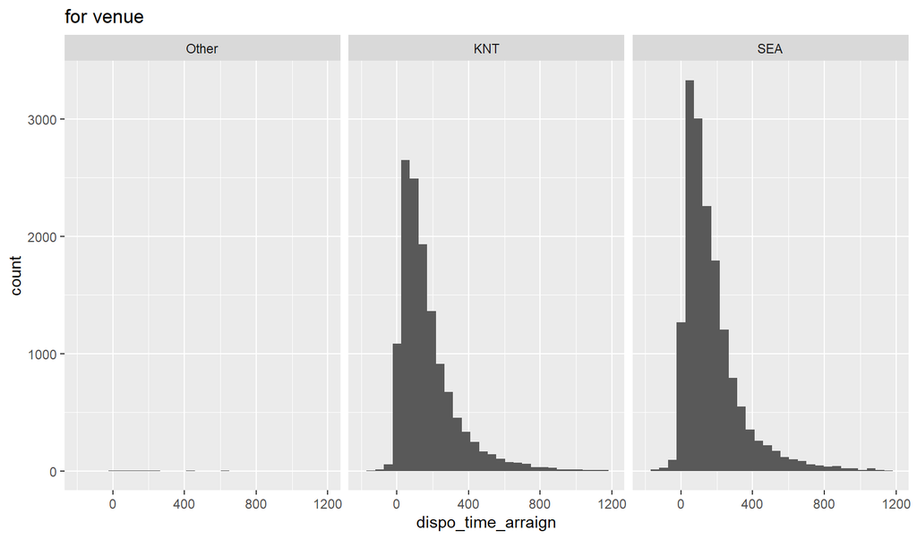

```r
#-----------------------------------------------------

# disposition time comparing last arraignment date for venue
ggplot(dispo_by_category,aes(x=dispo_time_arraign)) +
  geom_histogram()  +
    xlim(c(-200,1200)) + facet_grid(~venue) + ggtitle("for venue")
```

```r
# venue
summaryBy(dispo_time_arraign ~ venue, data = dispo_by_category,
          FUN = list(mean, max, min, median), na.rm=TRUE)
```

```
##   venue dispo_time_arraign.mean dispo_time_arraign.max
## 1 Other                198.2727                    616
## 2   KNT                169.9616                   1871
## 3   SEA                168.3532                   1719
##   dispo_time_arraign.min dispo_time_arraign.median
## 1                      0                       136
## 2                  -2723                       125
## 3                  -5700                       125
```

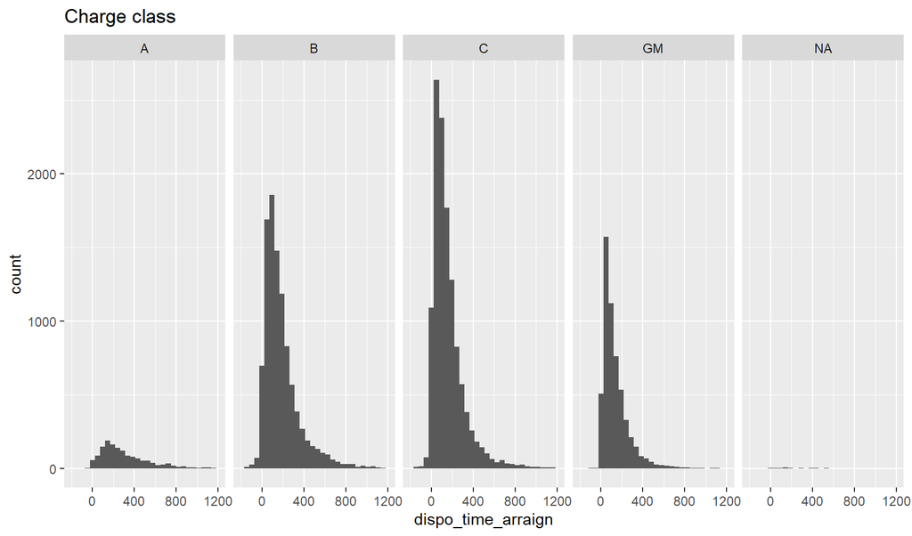

```r
#-----------------------------------------------------

# disposition time comparing last arraignment date for Charge class
ggplot(dispo_by_category,aes(x=dispo_time_arraign)) +
  geom_histogram()  +
    xlim(c(-200,1200)) + facet_grid(~class) + ggtitle("Charge class")
```

```r
# class
summaryBy(dispo_time_arraign ~ class, data = dispo_by_category,
          FUN = list(mean, max, min, median), na.rm=TRUE)
```

```
##   class dispo_time_arraign.mean dispo_time_arraign.max
## 1     A                299.9274                   1871
## 2     B                184.2357                   1611
## 3     C                156.4844                   1754
## 4    GM                135.4129                   1219
## 5  <NA>                163.5714                    523
##   dispo_time_arraign.min dispo_time_arraign.median
## 1                   -241                     238.5
## 2                  -1721                     140.0
## 3                  -5700                     117.0
## 4                  -2536                      99.0
## 5                    -10                     153.0
```

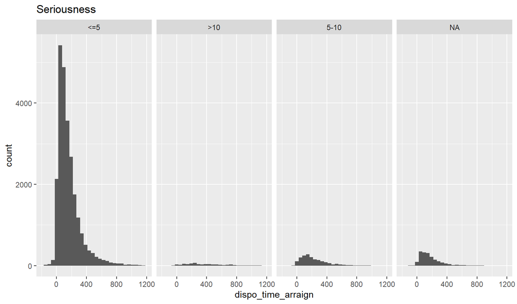

```r
#-----------------------------------------------------

# disposition time comparing last arraignment date for Seriousness
ggplot(dispo_by_category,aes(x=dispo_time_arraign)) +
  geom_histogram()  +
    xlim(c(-200,1200)) + facet_grid(~serious_cat) + ggtitle("Seriousness")
```

```r
# serious_cat
summaryBy(dispo_time_arraign ~ serious_cat, data = dispo_by_category,
          FUN = list(mean, max, min, median), na.rm=TRUE)
```

```
##   serious_cat dispo_time_arraign.mean dispo_time_arraign.max
## 1         <=5                159.9835                   1754
## 2         >10                377.2564                   1719
## 3        5-10                222.9921                   1871
## 4        <NA>                173.6987                   1323
##   dispo_time_arraign.min dispo_time_arraign.median
## 1                  -5700                       119
## 2                   -241                       317
## 3                   -460                       177
## 4                   -237                       140
```

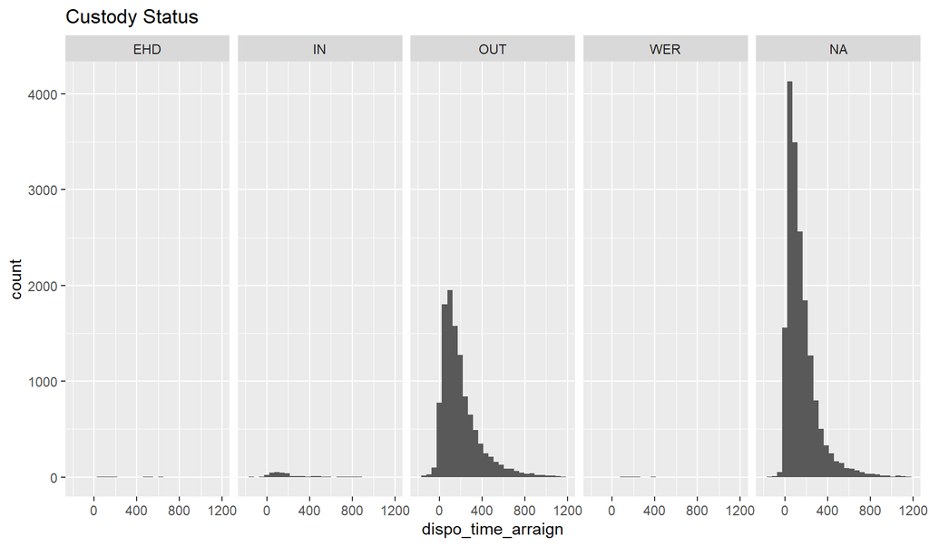

```r
#-----------------------------------------------------

# disposition time comparing last arraignment date for Custody Status
ggplot(dispo_by_category,aes(x=dispo_time_arraign)) +
  geom_histogram()  +
    xlim(c(-200,1200)) + facet_grid(~defendant_status) + ggtitle("Custody Status")
```

```r
# defendant_status
summaryBy(dispo_time_arraign ~ defendant_status, data = dispo_by_category,
          FUN = list(mean, max, min, median), na.rm=TRUE)
```

```
##   defendant_status dispo_time_arraign.mean dispo_time_arraign.max
## 1              EHD                247.9000                    609
## 2               IN                175.0968                    865
## 3              OUT                192.6370                   1754
## 4              WER                195.7143                    373
## 5             <NA>                154.0957                   1871
##   dispo_time_arraign.min dispo_time_arraign.median
## 1                     40                       169
## 2                   -882                       133
## 3                  -2880                       146
## 4                    105                       205
## 5                  -5700                       114
```

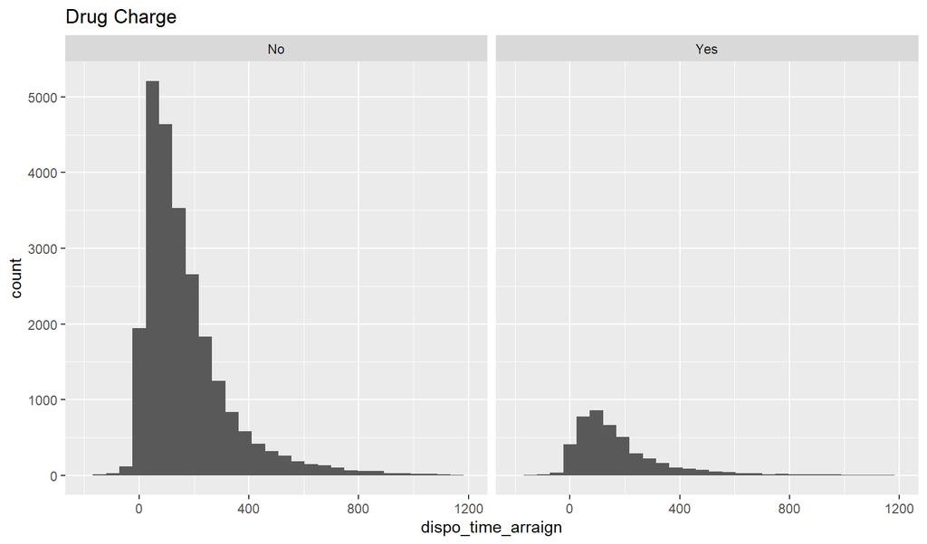

```r
#-----------------------------------------------------

# disposition time comparing last arraignment date for Drug Cases
ggplot(dispo_by_category,aes(x=dispo_time_arraign)) +
  geom_histogram()  +
    xlim(c(-200,1200)) + facet_grid(~drug_charge) + ggtitle("Drug Charge")
```

```r
# drug_court
summaryBy(dispo_time_arraign ~ drug_charge, data = dispo_by_category,
          FUN = list(mean, max, min, median), na.rm=TRUE)
```

```
##   drug_charge dispo_time_arraign.mean dispo_time_arraign.max
## 1          No                168.1771                   1871
## 2         Yes                174.1000                   1591
##   dispo_time_arraign.min dispo_time_arraign.median
## 1                  -2880                       125
## 2                  -5700                       128
```

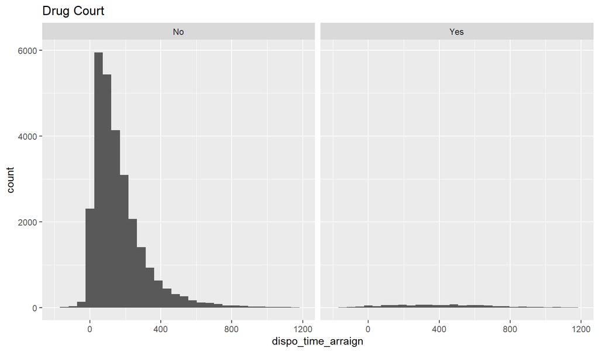

```r
#-----------------------------------------------------

# disposition time comparing last arraignment date for Drug Cases
ggplot(dispo_by_category,aes(x=dispo_time_arraign)) +
  geom_histogram()  +
    xlim(c(-200,1200)) + facet_grid(~drug_court) + ggtitle("Drug Court")
```

```r
# drug_court
summaryBy(dispo_time_arraign ~ drug_court, data = dispo_by_category,
          FUN = list(mean, max, min, median), na.rm=TRUE)
```

```
##   drug_court dispo_time_arraign.mean dispo_time_arraign.max
## 1         No                159.6081                   1871
## 2        Yes                417.1940                   1363
##   dispo_time_arraign.min dispo_time_arraign.median
## 1                  -5700                       121
## 2                   -793                       396
```

```r
#-----------------------------------------------------
```